# Plotting in R

Even Garvang

Spring 2019

This guide is a part of a series of short tutorials. Find all the tutorials [here](https://evengar.github.io/short-tutorials/).

# 1 Introduction

R is a powerful tool for visualising your data. You can make almost any kind of plot, revealing connections that are hard to see from summary statistics. This tutorial is not meant to be a comprehensice guide on plotting in R, but rather a starting point, introducing the most important methods.

Section 3 is optional, and introduces ggplot2, a different system for plotting in R.

## 1.1 Why visualise your data?

You may think that communication is the most important reason for visualising your data. This is partly true, as a good graph can convey a lot of information more easily than text or tables. Hovever, you will find that you make a lot of graphs that you never show to others. These are graphs that you make for yourself to investigate connections in the data. Visualisations are not only important for communication, but also for the process of data exploration.

For learning about the powers of data visualisation, as well as the do’s and dont’s of making graphs, I recommend the book [Data Visualization](https://socviz.co/) by Kieran Healy.

## 1.2 Prerequisites

For this exercise we will only use base R and its built-in `iris` data set. For the optional section 3 you will need the `ggplot2` package, that you can install by running `install.packages("ggplot2")`.

# 2 Plotting in R

The basic function for plotting in R is simply `plot()`. This function will guess what kind of plot to make based on the data you provide. You can supply many arguments to the `plot()` function to get the visualisation you want, which we will gradually go through here.

## 2.1 Plotting vectors

The simplest way of plotting in R is by plotting two vectors of equal length. One vector gives the x-value, and another gives the y-value.

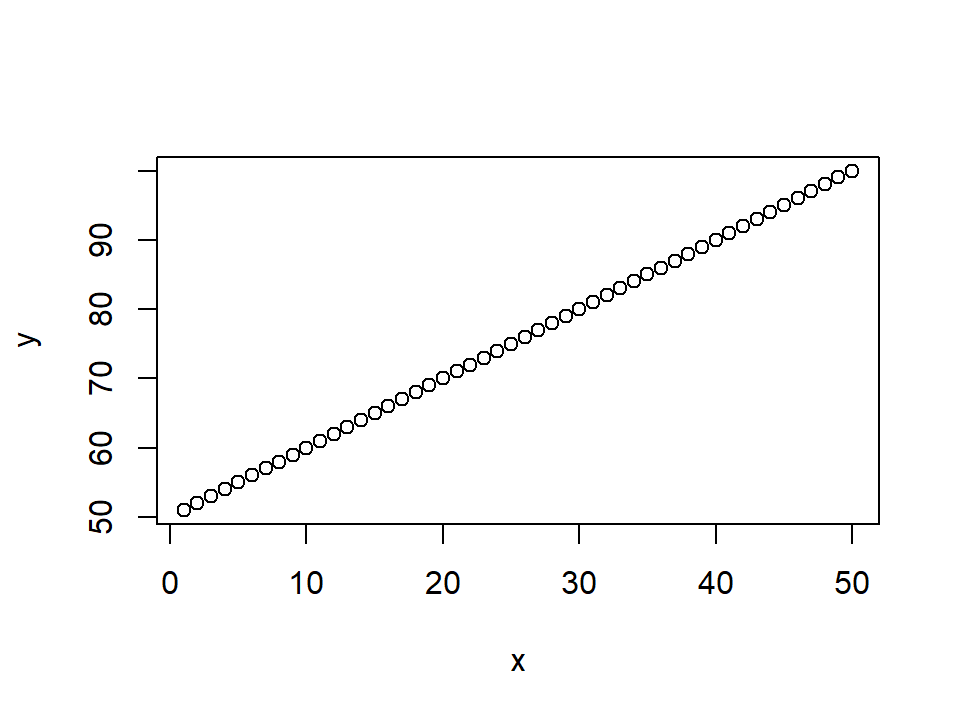

```r
# make two vectors of equal length
x <- 1:50
y <- 51:100

plot(x, y)
```

As you can see, it makes a simple plot of our data, using points as the default. If we want to make a line graph we have to specify `type = "l"`:

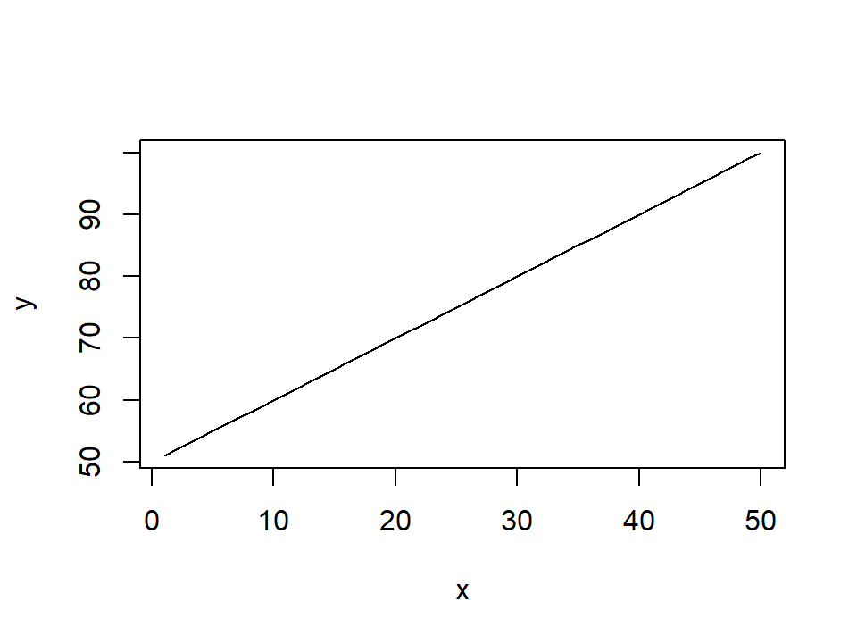

```r
plot(x, y, type = "l")
```

For all the different ´type´ arguments, see the plot-function’s help page by running `?plot`.

**Tip:** Remember that when you use R’s `$` operator to pick out a single column from a data frame, you create a vector. Using this, you can easily plot the columns of your data frame. Another way of doing this is introduced in section 2.3.

## 2.2 Plotting functions

You can also plot simple functions easily with the `plot()` function. You don’t have to give an x-value when plotting this way, and you can control what x-values to show with the `xlim` argument.

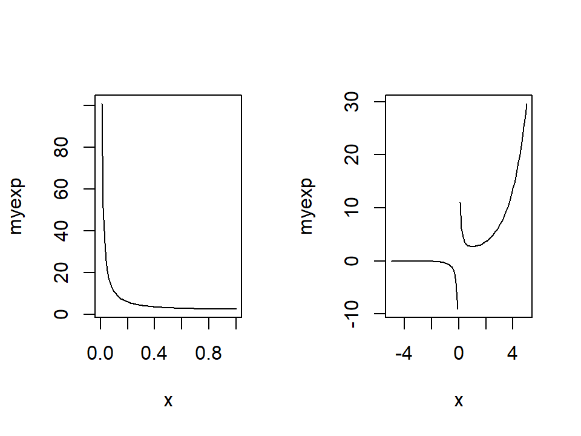

Figure 2.1: Plotting the function “myexp”. Right: controlling the x-value to range between -5 and 5.

```r
# define a function
myexp <- function(x){
  exp(x)/x
}

# fit two plots in one window using par()
par(mfrow = c(1, 2))

# plot with default xlim
plot(myexp)

# plot with x in a range between -5 and 5
plot(myexp, xlim = c(-5, 5))
```

```r
# reset parameters to one plot per window
par(mfrow = c(1, 1))
```

Notice how the plot-function again guesses that we want lines for our graph. Remember that you can change this with `type`.

## 2.3 Plotting data frames

The thing you probably will plot most often is data frames, containing your own or someone else’s data. For this part we will use the `iris` data set, which is a built-in data set in R (which means you don’t need to load it in any way). We start by inspecting the object:

```r
summary(iris)
```

```
#>   Sepal.Length    Sepal.Width     Petal.Length    Petal.Width
#>  Min.   :4.300   Min.   :2.000   Min.   :1.000   Min.   :0.100
#>  1st Qu.:5.100   1st Qu.:2.800   1st Qu.:1.600   1st Qu.:0.300
#>  Median :5.800   Median :3.000   Median :4.350   Median :1.300
#>  Mean   :5.843   Mean   :3.057   Mean   :3.758   Mean   :1.199
#>  3rd Qu.:6.400   3rd Qu.:3.300   3rd Qu.:5.100   3rd Qu.:1.800
#>  Max.   :7.900   Max.   :4.400   Max.   :6.900   Max.   :2.500
#>        Species
#>  setosa    :50
#>  versicolor:50
#>  virginica :50
#>
#>
#>
```

As you can see, it contains four continous measurements for 50 individuals each from three different species of *Iris*. We could just simply write `plot(iris)`, which plots all the values against each other:

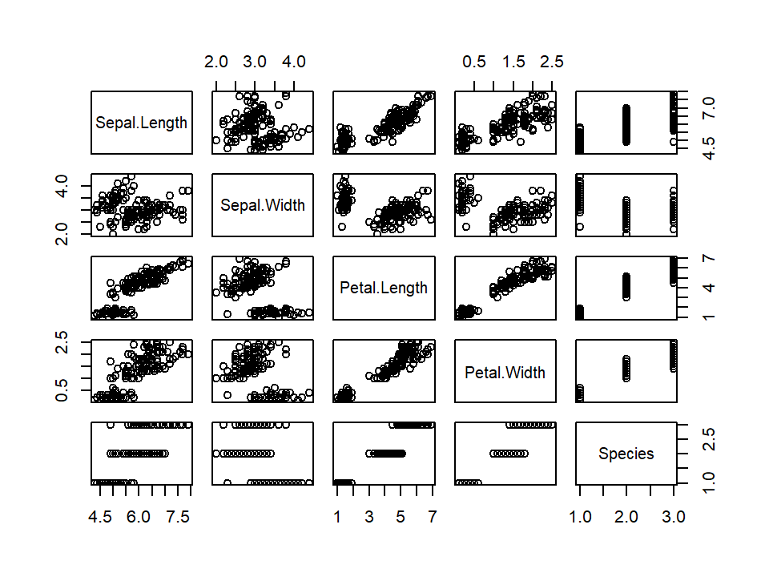

Figure 2.2: A plot of the entire iris data set.

```r
plot(iris)
```

Even for this relatively small data set this visualisation can be quite overwhelming. While this kind of plotting can be useful to get an overview, we often want to focus on specific relationships between our data. To plot two values against each other you use the following syntax: `plot(response_variable ~ explanatory_variable, data = my_data)`. If we want to investigate the relationship between petal length and sepal length in the `iris` data, we would do the following:

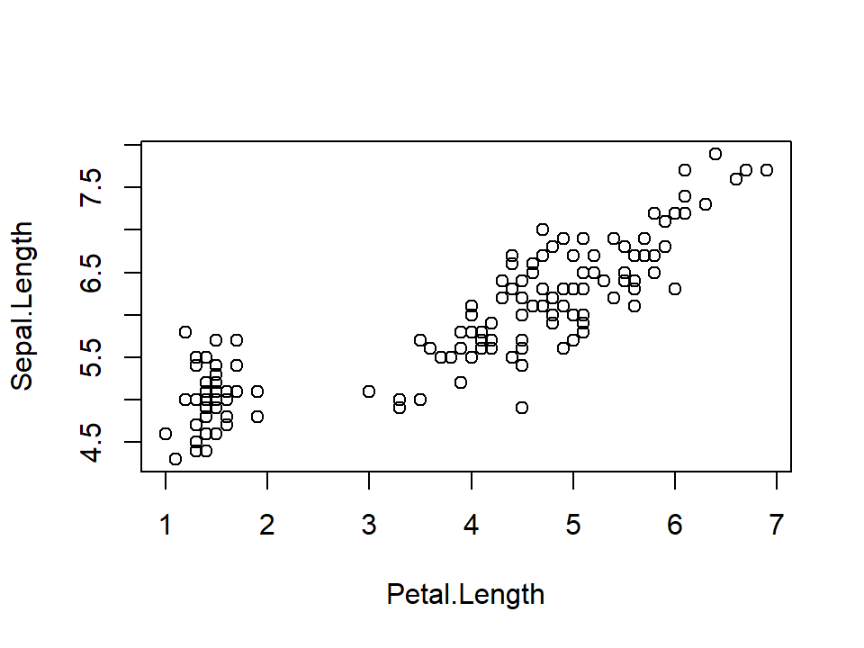

Figure 2.3: Sepal length vs. petal length

```r
plot(Sepal.Length ~ Petal.Length, data = iris)
```

We get a nice scatterplot of those data. There is some pattern here, which we will explore later, in section 2.5.2. If we want to plot numerical data (e.g. petal width) as a function of categorical data (here species), the approach is the same:

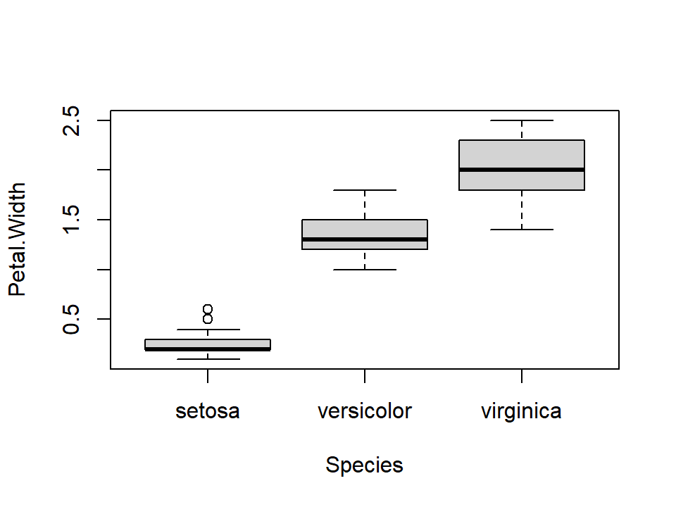

Figure 2.4: R automatically assumed you wanted a boxplot!

```r
plot(Petal.Width ~ Species, data = iris)
```

The plotting function automatically makes a boxplot! When presented with one categorical and one numeric variable, R assumes that a boxplot is the best way to present that data. Be careful with this behavior, as R aren’t always right about this. You should always think about how *you* want to present your data, rather than going with what R suggests[^1].

Often, you don’t want R to guess for you, but rather specify yourself what you want to plot, leading us into the next section.

## 2.4 Special plot commands (histograms, boxplots, barcharts etc.)

While `plot()` is good for a lot of things, you’ll want other things than scatterplots and boxplots. Then you have to use different functions for making your plot:

- `barplot()` for barplots
- `hist()` for histograms
- `boxplot` for boxplots

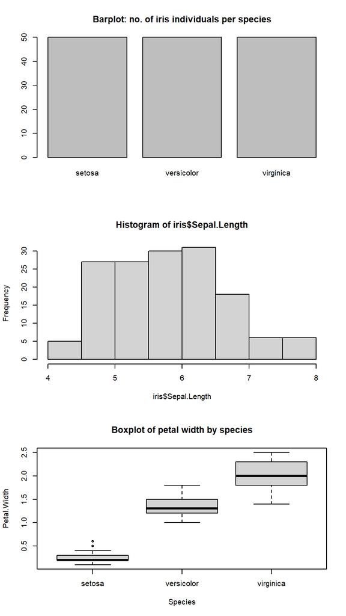

Figure 2.5: Examples of special plot commands

```r
# examples
par(mfrow = c(3, 1))

barplot(table(iris$Species), main = "Barplot: no. of iris individuals per species")
hist(iris$Sepal.Length)
boxplot(Petal.Width ~ Species, data = iris, main = "Boxplot of petal width by species")
```

```r
par(mfrow = c(1,1))
```

Additionally, some functions add elements to an existing plot instead of creating a new one:

- `lines()` add lines on top
- `points()` add points on top

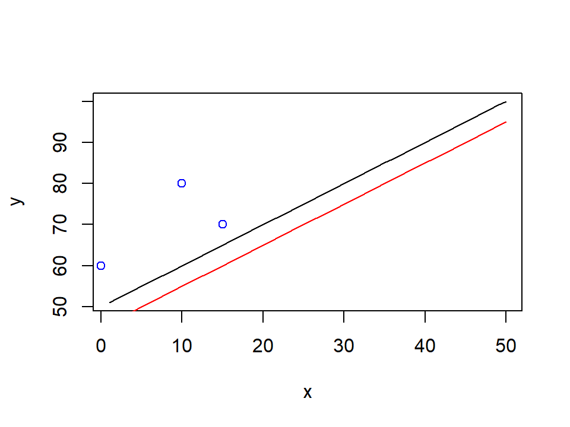

Figure 2.6: Plot with added line (red) and added points (blue)

```r
plot(x, y, type = "l")
lines(x, y - 5, col = "red")
points(c(0, 10, 15), c(60, 80, 70), col = "blue")
```